# TASK - VI - LINEAR ALGEBRA

### LINEAR ALGEBRA: A branch of mathematics that is concerned with mathematical structures closed under the operations of addition and scalar multiplication and that includes the theory of systems of linear equations, matrices, determinants, vector spaces, and linear transformations.

### Why it is called as Linear Algebra?

### Linear algebra is called linear because it is the study of straight lines. A linear function is any function that graphs to a straight line, and linear algebra is the mathematics for solving systems that are modeled with multiple linear functions. Multiple linear equations can be expressed as vectors and matrices.

```python
import numpy as np
import matplotlib.pyplot as plt
from mpl_toolkits.mplot3d import Axes3D
```

```python
p = [3, 4]
q = [1, 2, 3]
```

```python
p, q
```

```
([3, 4], [1, 2, 3])
```

```python
type(q)
```

```
list
```

```python
w = np.array([9, 5, 7])
```

```python
type(w)
```

```
numpy.ndarray
```

```python
w.shape[0]
```

```
3
```

```python
w.shape
```

```
(3,)
```

### Reading elements from an array

```python
a = np.array([7, 5, 3, 9, 0, 2])
```

```python
a[0]
```

```
7
```

```python
a[1:]
```

```
array([5, 3, 9, 0, 2])
```

```python
a[1:4]
```

```
array([5, 3, 9])
```

```python
a[-1]
```

```
2
```

```python
a[-3]
```

```
9
```

```python
a[-6]
```

```
7
```

```python
a[-3:-1]
```

```
array([9, 0])
```

## Plotting a Vector

### Vector: A vector is an object that has both a magnitude and a direction. Geometrically, we can picture a vector as a directed line segment, whose length is the magnitude of the vector and with an arrow indicating the direction. Two examples of vectors are those that represent force and velocity.

```python
p = [3, 4]
q = [1, 2, 3]
```

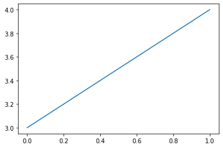

```python
plt.plot(p)
```

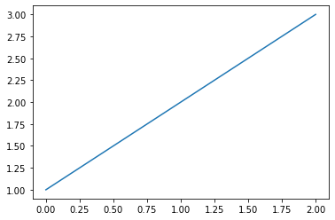

```python
plt.plot(q)
```

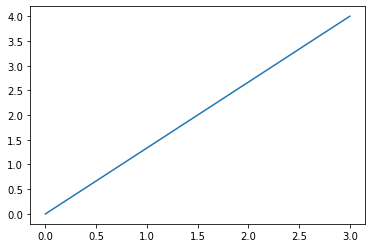

```python
plt.plot([0, p[0]], [0,p[1]])
```

### Plot 2D Vector

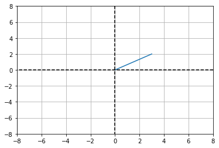

```python
plt.plot([0, p[0]], [0, q[1]])

plt.plot([8,-8] , [0,0] , 'k--')

plt.plot([0,0] , [8,-8] , 'k--')

plt.grid()

plt.axis((-8, 8, -8, 8))

plt.show()
```

### Plot the 3D vector

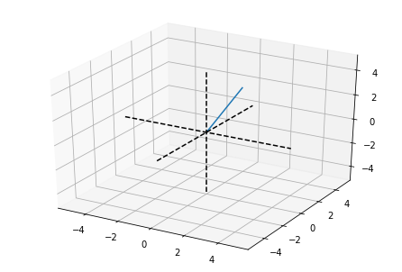

```python
fig = plt.figure()

ax = Axes3D(fig)

ax.plot([0, q[0]], [0, q[1]],[0, q[2]])

ax.plot([0, 0],[0, 0],[-5, 5],'k--')

ax.plot([0, 0],[-5, 5],[0, 0],'k--')

ax.plot([-5, 5],[0, 0],[0, 0],'k--')

plt.show()
```

```
P3 =  [4 6]
```

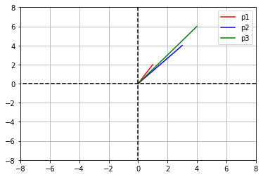

```python
p1 = np.array([1, 2])

p2 = np.array([3, 4])

p3 = p1 + p2

p3 = np.add(p1, p2)

print('P3 = ', p3)

plt.plot([0, p1[0]], [0,p1[1]], 'r' , label = 'p1')

plt.plot([0, p2[0]], [0,p2[1]], 'b' , label = 'p2')

plt.plot([0, p3[0]], [0,p3[1]], 'g' , label = 'p3')

plt.plot([8,-8], [0,0], 'k--')

plt.plot([0,0], [8,-8], 'k--')

plt.grid()

plt.axis((-8, 8, -8, 8))

plt.legend()

plt.show()
```

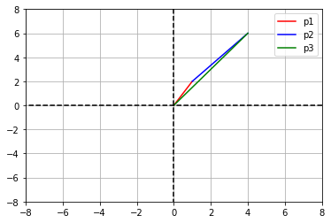

```python
plt.plot([0, p1[0]], [0,p1[1]], 'r', label = 'p1')

plt.plot([0, p2[0]] + p1[0], [0, p2[1]] + p1[1], 'b' , label = 'p2')

plt.plot([0, p3[0]], [0, p3[1]] , 'g' , label = 'p3')

plt.plot([8,-8] , [0,0] , 'k--')

plt.plot([0,0] , [8,-8] , 'k--')

plt.grid()

plt.axis((-8, 8, -8, 8))

plt.legend()

plt.show()
```

### Scalar Multiplication: A operation used in the definition of a vector space in which the product of a scalar and a vector is a vector. The operation is distributive over the addition of both scalars and vectors, and is associative with multiplication of scalars.

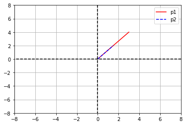

```python
q1 = np.array([3,4])

a = .5

q2 = q1*a

plt.plot([0, q1[0]], [0, q1[1]], 'r' , label = 'p1')

plt.plot([0, q2[0]], [0, q2[1]], 'b--', label = 'p2')

plt.plot([8,-8] , [0,0] , 'k--')

plt.plot([0,0] , [8,-8] , 'k--')

plt.grid()

plt.axis((-8, 8, -8, 8))

plt.legend()

plt.show()
```

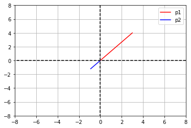

```python
q1 = np.array([3, 4])

a = -.3

q2 = q1*a

plt.plot([0, q1[0]], [0, q1[1]], 'r', label = 'p1')

plt.plot([0, q2[0]], [0, q2[1]], 'b', label = 'p2')

plt.plot([8,-8] , [0,0] , 'k--')

plt.plot([0,0] , [8,-8] , 'k--')

plt.grid()

plt.axis((-8, 8, -8, 8))

plt.legend()

plt.show()
```

### Multiplication of vectors: Vector multiplication refers to one of several techniques for the multiplication of two (or more) vectors with themselves. Alternatively, it is defined as the product of the projection of the first vector onto the second vector and the magnitude of the second vector.

```python
a1 = [5, 6, 8]
a2 = [4, 7, 9]
print(np.multiply(a1, a2))
```

```
[20 42 72]
```

### Dot Product: The dot product is an operation that takes two vectors as input, and that returns a scalar number as output. The name is derived from the centered dot " · " that is often used to designate this operation; the alternative name scalar product emphasizes the scalar (rather than vector) nature of the result.

```python
a1 = np.array([1, 2, 3])

a2 = np.array([4, 5, 6])

dotp = a1@a2

print(" Dot product - ", dotp)

dotp = np.dot(a1,a2)

print(" Dot product usign np.dot", dotp)

dotp = np.inner(a1, a2)

print(" Dot product usign np.inner", dotp)

dotp = sum(np.multiply(a1, a2))

print(" Dot product usign np.multiply & sum", dotp)

dotp = np.matmul(a1,a2)

print(" Dot product usign np.matmul", dotp)

dotp = 0

for i in range(len(a1)):
    dotp = dotp + a1[i]*a2[i]

    print(" Dot product usign for loop", dotp)
```

```
 Dot product -  32
 Dot product usign np.dot 32
 Dot product usign np.inner 32
 Dot product usign np.multiply & sum 32
 Dot product usign np.matmul 32
 Dot product usign for loop 4
 Dot product usign for loop 14
 Dot product usign for loop 32
```

### Length of Vector: It is the magnitude of the vector. The length or magnitude of a vector cannot be negative.

```python
v3 = np.array([1, 2, 3, 4, 5, 6])
length = np.sqrt(np.dot(v3, v3))
length
```

```
9.539392014169456
```

```python
v3 = np.array([1, 2, 3, 4, 5, 6])
length = np.sqrt(sum(np.multiply(v3, v3)))
length
```

```
9.539392014169456
```

```python
v3 = np.array([1, 2, 3, 4, 5, 6])
length = np.sqrt(np.matmul(v3, v3))
length
```

```
9.539392014169456
```

```python
v1 = [2, 3]
length_v1 = np.sqrt(np.dot(v1, v1))
norm_v1 = v1/length_v1
length_v1, norm_v1
```

```
(3.605551275463989, array([0.5547002 , 0.83205029]))
```

```python
v1 = [2, 3]
norm_v1 = v1/np.linalg.norm(v1)
norm_v1
```

```
array([0.5547002 , 0.83205029])
```

### Angle between vectors: The angle between two vectors u and v is the angle θ that satisfies: 0 <= θ <= 180° This definition works for both 2D space and 3D space. The angle is the smallest angle that one vector can be rotated until it aligns with the other.

#### First Method

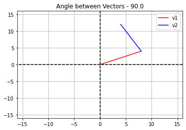

```python
v1 = np.array([8, 4])

v2 = np.array([-4, 8])

ang = np.rad2deg(np.arccos( np.dot(v1,v2) / (np.linalg.norm(v1)*np.linalg.norm(v2))))

plt.plot([0, v1[0]], [0, v1[1]], 'r', label = 'v1')

plt.plot([0, v2[0]] + v1[0], [0, v2[1]] + v1[1], 'b', label = 'v2')

plt.plot([16, -16], [0, 0], 'k--')

plt.plot([0, 0], [16, -16], 'k--')

plt.grid()

plt.axis((-16, 16, -16, 16))

plt.legend()

plt.title('Angle between Vectors - %s' %ang)

plt.show()
```

#### Second Method

```python
v1 = np.array([4, 3])

v2 = np.array([-3, 4])

lengthV1 = np.sqrt(np.dot(v1, v1))

lengthV2 = np.sqrt(np.dot(v2, v2))

ang = np.rad2deg(np.arccos( np.dot(v1, v2) / (lengthV1 * lengthV2)))

print('Angle between Vectors - %s' %ang)
```

```
Angle between Vectors - 90.0
```

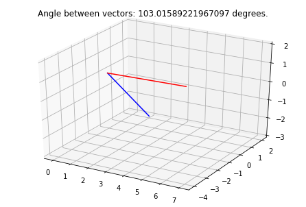

```python
v1 = np.array([1, 2, -3])

v2 = np.array([7, -4, 2])

fig = plt.figure()

ax = Axes3D(fig)

ax.plot([0, v1[0]], [0, v1[1]], [0, v1[2]], 'b')

ax.plot([0, v2[0]], [0, v2[1]], [0, v2[2]], 'r')

ang = np.rad2deg(np.arccos( np.dot(v1,v2) / (np.linalg.norm(v1)*np.linalg.norm(v2)) ))

plt.title('Angle between vectors: %s degrees.' %ang)
```

### Inner & outer products

```python
v1 = np.array([1, 2, 3])

v2 = np.array([4, 5, 6])

np.inner(v1, v2)

print("\n Inner Product ==> \n", np.inner(v1, v2))

print("\n Outer Product ==> \n", np.outer(v1, v2))
```

```
 Inner Product ==>
 32

 Outer Product ==>
 [[ 4  5  6]
 [ 8 10 12]
 [12 15 18]]
```

### Vector Cross Product: The cross product a × b is defined as a vector c that is perpendicular (orthogonal) to both a and b, with a direction given by the right-hand rule and a magnitude equal to the area of the parallelogram that the vectors span.

```python
v1 = np.array([1, 2, 3])

v2 = np.array([4, 5, 6])

print("\nVector Cross Product ==> \n", np.cross(v1, v2))
```

```
Vector Cross Product ==>
 [-3  6 -3]
```

## Matrix Operations

### Matrix Creation

```python
A = np.array([[1, 2, 3, 4], [5, 6, 7, 8], [10, 11, 12, 13], [14, 15, 16, 17]])
```

```python
A
```

```
array([[ 1,  2,  3,  4],
       [ 5,  6,  7,  8],
       [10, 11, 12, 13],
       [14, 15, 16, 17]])
```

```python
type(A)
```

```
numpy.ndarray
```

```python
A.dtype
```

```
dtype('int32')
```

```python
B = np.array([[1.5, 2.07, 3, 4], [5, 6, 7, 8], [10, 11, 12, 13], [14, 15, 16, 17]])
```

```python
B
```

```
array([[ 1.5 ,  2.07,  3.  ,  4.  ],
       [ 5.  ,  6.  ,  7.  ,  8.  ],
       [10.  , 11.  , 12.  , 13.  ],
       [14.  , 15.  , 16.  , 17.  ]])
```

```python
type(B)
```

```
numpy.ndarray
```

```python
B.dtype
```

```
dtype('float64')
```

```python
A.shape
```

```
(4, 4)
```

```python
A[0,]
```

```
array([1, 2, 3, 4])
```

```python
A[:,0]
```

```
array([ 1,  5, 10, 14])
```

```python
A[0,0]
```

```
1
```

```python
A[0][0]
```

```
1
```

```python
A[1:3, 1:3]
```

```
array([[ 6,  7],
       [11, 12]])
```

### Matrix Types:

```python
np.zeros(9).reshape(3, 3)
```

```
array([[0., 0., 0.],
       [0., 0., 0.],
       [0., 0., 0.]])
```

```python
np.zeros((3, 3))
```

```
array([[0., 0., 0.],
       [0., 0., 0.],
       [0., 0., 0.]])
```

## Matrix of Ones

```python
np.ones(9).reshape(3, 3)
```

```
array([[1., 1., 1.],
       [1., 1., 1.],
       [1., 1., 1.]])
```

```python
np.ones((3,3))
```

```
array([[1., 1., 1.],
       [1., 1., 1.],
       [1., 1., 1.]])
```

### Matrix with Random Numbers

```python
X = np.random.random((3, 3))
X
```

```
array([[0.30974265, 0.48405757, 0.0180444 ],
       [0.43430368, 0.10671144, 0.76880088],
       [0.12882238, 0.60250598, 0.45856584]])
```

```python
I = np.eye(9)
I
```

```
array([[1., 0., 0., 0., 0., 0., 0., 0., 0.],
       [0., 1., 0., 0., 0., 0., 0., 0., 0.],
       [0., 0., 1., 0., 0., 0., 0., 0., 0.],
       [0., 0., 0., 1., 0., 0., 0., 0., 0.],
       [0., 0., 0., 0., 1., 0., 0., 0., 0.],
       [0., 0., 0., 0., 0., 1., 0., 0., 0.],
       [0., 0., 0., 0., 0., 0., 1., 0., 0.],
       [0., 0., 0., 0., 0., 0., 0., 1., 0.],
       [0., 0., 0., 0., 0., 0., 0., 0., 1.]])
```

### Diagonal Matrix: A diagonal matrix is a matrix in which the entries outside the main diagonal are all zero; the term usually refers to square matrices. A diagonal matrix is one where values outside of the main diagonal have a zero value, where the main diagonal is taken from the top left of the matrix to the bottom right.

```python
D = np.diag([1, 2, 3, 4, 5, 6, 7, 8])
D
```

```
array([[1, 0, 0, 0, 0, 0, 0, 0],
       [0, 2, 0, 0, 0, 0, 0, 0],
       [0, 0, 3, 0, 0, 0, 0, 0],
       [0, 0, 0, 4, 0, 0, 0, 0],
       [0, 0, 0, 0, 5, 0, 0, 0],
       [0, 0, 0, 0, 0, 6, 0, 0],
       [0, 0, 0, 0, 0, 0, 7, 0],
       [0, 0, 0, 0, 0, 0, 0, 8]])
```

### Traingular Matrices (lower & Upper triangular matrix)

```python
M = np.random.randn(5, 5)

U = np.triu(M)

L = np.tril(M)

print("lower triangular matrix - \n", M)

print("\n")

print("lower triangular matrix - \n", L)

print("\n")

print("Upper triangular matrix - \n", U)
```

```
lower triangular matrix -
 [[ 0.38846104 -1.7243919   0.55736764 -0.57350722  1.65267915]
 [ 1.16953313 -1.5550096  -1.67133713  0.3731605  -0.73036101]
 [-2.30490916 -0.45042995 -1.97135084  0.35363824 -1.0008108 ]
 [-0.39821671  0.90172505 -1.37430856 -0.4293203  -0.89579737]
 [ 0.57224582 -0.16737226  0.46120859 -1.12857652  1.12892714]]


lower triangular matrix -
 [[ 0.38846104  0.          0.          0.          0.        ]
 [ 1.16953313 -1.5550096   0.          0.          0.        ]
 [-2.30490916 -0.45042995 -1.97135084  0.          0.        ]
 [-0.39821671  0.90172505 -1.37430856 -0.4293203   0.        ]
 [ 0.57224582 -0.16737226  0.46120859 -1.12857652  1.12892714]]


Upper triangular matrix -
 [[ 0.38846104 -1.7243919   0.55736764 -0.57350722  1.65267915]
 [ 0.         -1.5550096  -1.67133713  0.3731605  -0.73036101]
 [ 0.          0.         -1.97135084  0.35363824 -1.0008108 ]
 [ 0.          0.          0.         -0.4293203  -0.89579737]
 [ 0.          0.          0.          0.          1.12892714]]
```

### Concatenate Matrices: Matrix concatenation is the process of joining one or more matrices to make a new matrix. The expression C = [A B] horizontally concatenates matrices A and B . The expression C = [A; B] vertically concatenates them.

```python
A = np.array([[1, 2], [3, 4], [5, 6]])

B = np.array([[1, 1], [1, 1]])

C = np.concatenate((A, B))

C, C.shape, type(C), C.dtype
```

```
(array([[1, 2],
        [3, 4],
        [5, 6],
        [1, 1],
        [1, 1]]),
 (5, 2),
 numpy.ndarray,
 dtype('int32'))
```

```python
np.full((5,5), 8)
```

```
array([[8, 8, 8, 8, 8],
       [8, 8, 8, 8, 8],
       [8, 8, 8, 8, 8],
       [8, 8, 8, 8, 8],
       [8, 8, 8, 8, 8]])
```

```python
M
```

```
array([[ 0.38846104, -1.7243919 ,  0.55736764, -0.57350722,  1.65267915],
       [ 1.16953313, -1.5550096 , -1.67133713,  0.3731605 , -0.73036101],
       [-2.30490916, -0.45042995, -1.97135084,  0.35363824, -1.0008108 ],
       [-0.39821671,  0.90172505, -1.37430856, -0.4293203 , -0.89579737],
       [ 0.57224582, -0.16737226,  0.46120859, -1.12857652,  1.12892714]])
```

```python
M.flatten()
```

```
array([ 0.38846104, -1.7243919 ,  0.55736764, -0.57350722,  1.65267915,
        1.16953313, -1.5550096 , -1.67133713,  0.3731605 , -0.73036101,
       -2.30490916, -0.45042995, -1.97135084,  0.35363824, -1.0008108 ,
       -0.39821671,  0.90172505, -1.37430856, -0.4293203 , -0.89579737,
        0.57224582, -0.16737226,  0.46120859, -1.12857652,  1.12892714])
```

### Matrix Addition: matrix addition is the operation of adding two matrices by adding the corresponding entries together. However, there are other operations which could also be considered addition for matrices, such as the direct sum and the Kronecker sum.

```python
M = np.array([[1, 2, 3], [4, -3, 6], [7, 8, 0]])

N = np.array([[1, 1, 1], [2, 2, 2], [3, 3, 3]])

print("\n First Matrix (M) ==> \n", M)

print("\n Second Matrix (N) ==> \n", N)

C = M + N

print("\n Matrix Addition (M + N) ==> \n", C)

# OR

C = np.add(M, N, dtype = np.float64)

print("\n Matrix Addition using np.add ==> \n", C)
```

```
 First Matrix (M) ==>
 [[ 1  2  3]
 [ 4 -3  6]
 [ 7  8  0]]

 Second Matrix (N) ==>
 [[1 1 1]
 [2 2 2]
 [3 3 3]]

 Matrix Addition (M + N) ==>
 [[ 2  3  4]
 [ 6 -1  8]
 [10 11  3]]

 Matrix Addition using np.add ==>
 [[ 2.  3.  4.]
 [ 6. -1.  8.]
 [10. 11.  3.]]
```

### Matrix subtraction: Two matrices A and B are said to be conformable for subtraction if they have the same order (i.e. same number of rows and columns) and their difference A - B is defined to be the addition of A and (-B). i.e., A – B = A + (-B)

```python
M = np.array([[1, 2, 3], [4, -3, 6], [7, 8, 0]])

N = np.array([[1, 1, 1], [2, 2, 2], [3, 3, 3]])

print("\n First Matrix (M) ==> \n", M)

print("\n Second Matrix (N) ==> \n", N)

C = M - N

print("\n Matrix Subtraction (M - N) ==> \n", C)

# OR

C = np.subtract(M, N, dtype = np.float64)

print("\n Matrix Subtraction using np.subtract ==> \n", C)
```

```
 First Matrix (M) ==>
 [[ 1  2  3]
 [ 4 -3  6]
 [ 7  8  0]]

 Second Matrix (N) ==>
 [[1 1 1]
 [2 2 2]
 [3 3 3]]

 Matrix Subtraction (M - N) ==>
 [[ 0  1  2]
 [ 2 -5  4]
 [ 4  5 -3]]

 Matrix Subtraction using np.subtract ==>
 [[ 0.  1.  2.]
 [ 2. -5.  4.]
 [ 4.  5. -3.]]
```

### Matrices Scalar Multiplication: When we work with matrices, we refer to real numbers as scalars. The term scalar multiplication refers to the product of a real number and a matrix. In scalar multiplication, each entry in the matrix is multiplied by the given scalar.

```python
M = np.array([[1, 2, 3], [4, -3, 6], [7, 8, 0]])

C = 10

print("\n Matrix (M) ==> \n", M)

print("\nMatrices Scalar Multiplication ==> \n", C * M)

# OR

print("\nMatrices Scalar Multiplication ==> \n", np.multiply(C, M))
```

```
 Matrix (M) ==>
 [[ 1  2  3]
 [ 4 -3  6]
 [ 7  8  0]]

Matrices Scalar Multiplication ==>
 [[ 10  20  30]
 [ 40 -30  60]
 [ 70  80   0]]

Matrices Scalar Multiplication ==>
 [[ 10  20  30]
 [ 40 -30  60]
 [ 70  80   0]]
```

### Transpose of a matrix: The transpose of a matrix is simply a flipped version of the original matrix. We can transpose a matrix by switching its rows with its columns. We denote the transpose of matrix A by AT.

```python
M = np.array([[1, 2, 3], [4, -3, 6], [7, 8, 0]])

print("\n Matrix (M) ==> \n", M)

print("\nTranspose of M ==> \n", np.transpose(M))

# OR

print("\nTranspose of M ==> \n", M.T)
```

```
 Matrix (M) ==>
 [[ 1  2  3]
 [ 4 -3  6]
 [ 7  8  0]]

Transpose of M ==>
 [[ 1  4  7]
 [ 2 -3  8]
 [ 3  6  0]]

Transpose of M ==>
 [[ 1  4  7]
 [ 2 -3  8]
 [ 3  6  0]]
```

### Determinant of a matrix: The determinant is a scalar value that can be computed from the elements of a square matrix and encodes certain properties of the linear transformation described by the matrix. The determinant of a matrix A is denoted det(A), det A, or |A|.

```python
M = np.array([[1, 2, 3], [4, -3, 6], [7, 8, 0]])

print("\n Matrix (M) ==> \n", M)

print("\nDeterminant of M ==> ", np.linalg.det(M))
```

```
 Matrix (M) ==>
 [[ 1  2  3]
 [ 4 -3  6]
 [ 7  8  0]]

Determinant of M ==>  195.0
```

### Rank of a matrix: The rank of a matrix is defined as

### (a) the maximum number of linearly independent column vectors in the matrix (or)

### (b) the maximum number of linearly independent row vectors in the matrix. For an r x c matrix, If r is less than c, then the maximum rank of the matrix is r.

```python
M = np.array([[1, 2, 3], [4, -3, 6], [7, 8, 0]])

print("\n Matrix (M) ==> \n", M)

print("\nRank of M ==> ", np.linalg.matrix_rank(M))
```

```
 Matrix (M) ==>
 [[ 1  2  3]
 [ 4 -3  6]
 [ 7  8  0]]

Rank of M ==>  3
```

```python
M = np.array([[1, 2, 3], [4, -3, 6], [7, 8, 0]])

print("\n Matrix (M) ==> \n", M)

print("\nTrace of M ==> ", np.trace(M))
```

```
 Matrix (M) ==>
 [[ 1  2  3]
 [ 4 -3  6]
 [ 7  8  0]]

Trace of M ==>  -2
```

### Inverse of matrix: The concept of inverse of a matrix is a multidimensional generalization of the concept of reciprocal of a number: the product between a number and its reciprocal is equal to 1; the product between a square matrix and its inverse is equal to the identity matrix.

```python
M = np.array([[1, 2, 3], [4, -3, 6], [7, 8, 0]])

print("\n Matrix (M) ==> \n", M)

print("\nInverse of M ==> \n", np.linalg.inv(M))
```

```
 Matrix (M) ==>
 [[ 1  2  3]
 [ 4 -3  6]
 [ 7  8  0]]

Inverse of M ==>
 [[-0.24615385  0.12307692  0.10769231]
 [ 0.21538462 -0.10769231  0.03076923]
 [ 0.27179487  0.03076923 -0.05641026]]
```

### Matrix Multiplication (pointwise multiplication)

```python
M = np.array([[1, 2, 3], [4, -3, 6], [7, 8, 0]])

N = np.array([[1, 1, 1], [2, 2, 2], [3, 3, 3]])

print("\n First Matrix (M) ==> \n", M)

print("\n Second Matrix (N) ==> \n", N)

print("\n Point-Wise Multiplication of M & N ==> \n", M * N)

# OR

print("\n Point-Wise Multiplication of M & N ==> \n", np.multiply(M, N))
```

```
 First Matrix (M) ==>
 [[ 1  2  3]
 [ 4 -3  6]
 [ 7  8  0]]

 Second Matrix (N) ==>
 [[1 1 1]
 [2 2 2]
 [3 3 3]]

 Point-Wise Multiplication of M & N ==>
 [[ 1  2  3]
 [ 8 -6 12]
 [21 24  0]]

 Point-Wise Multiplication of M & N ==>
 [[ 1  2  3]
 [ 8 -6 12]
 [21 24  0]]
```

```python
M = np.array([[1, 2, 3], [4, -3, 6], [7, 8, 0]])

N = np.array([[1, 1, 1], [2, 2, 2], [3, 3, 3]])

print("\n First Matrix (M) ==> \n", M)

print("\n Second Matrix (N) ==> \n", N)

print("\n Matrix Dot Product ==> \n", M @ N)

# OR

print("\n Matrix Dot Product using np.matmul ==> \n", np.matmul(M, N))

# OR

print("\n Matrix Dot Product using np.dot ==> \n", np.dot(M, N))
```

```
 First Matrix (M) ==>
 [[ 1  2  3]
 [ 4 -3  6]
 [ 7  8  0]]

 Second Matrix (N) ==>
 [[1 1 1]
 [2 2 2]
 [3 3 3]]

 Matrix Dot Product ==>
 [[14 14 14]
 [16 16 16]
 [23 23 23]]

 Matrix Dot Product using np.matmul ==>
 [[14 14 14]
 [16 16 16]
 [23 23 23]]

 Matrix Dot Product using np.dot ==>
 [[14 14 14]
 [16 16 16]
 [23 23 23]]
```

```python
M = np.array([[1, 2, 3], [4, -3, 6], [7, 8, 0]])

N = np.array([[1, 1, 1], [2, 2, 2], [3, 3, 3]])

print("\n First Matrix (M) ==> \n", M)

print("\n Second Matrix (N) ==> \n", N)

print("\n Matrix Division (M/N) ==> \n", M/N)

# OR

print("\n Matrix Division (M/N) ==> \n", np.divide(M, N))
```

```
 First Matrix (M) ==>
 [[ 1  2  3]
 [ 4 -3  6]
 [ 7  8  0]]

 Second Matrix (N) ==>
 [[1 1 1]
 [2 2 2]
 [3 3 3]]

 Matrix Division (M/N) ==>
 [[ 1.          2.          3.        ]
 [ 2.         -1.5         3.        ]
 [ 2.33333333  2.66666667  0.        ]]

 Matrix Division (M/N) ==>
 [[ 1.          2.          3.        ]
 [ 2.         -1.5         3.        ]
 [ 2.33333333  2.66666667  0.        ]]
```

### Sum of all elements in a matrix

```python
N = np.array([[1, 1, 1], [2, 2, 2], [3, 3, 3]])

print("\n Matrix (N) ==> \n", N)

print ("Sum of all elements in a Matrix ==>")

print (np.sum(N))
```

```
 Matrix (N) ==>
 [[1 1 1]
 [2 2 2]
 [3 3 3]]
Sum of all elements in a Matrix ==>
18
```

### Column-Wise Addition

```python
N = np.array([[1, 1, 1], [2, 2, 2], [3, 3, 3]])

print("\n Matrix (N) ==> \n", N)

print ("Column-Wise summation ==>")

print (np.sum(N, axis = 0))
```

```
 Matrix (N) ==>
 [[1 1 1]
 [2 2 2]
 [3 3 3]]
Column-Wise summation ==>
[6 6 6]
```

### Row-Wise Addition

```python
N = np.array([[1, 1, 1], [2, 2, 2], [3, 3, 3]])

print("\n Matrix (N) ==> \n", N)

print ("Row-Wise summation ==>")

print (np.sum(N, axis = 1))
```

```
 Matrix (N) ==>
 [[1 1 1]
 [2 2 2]
 [3 3 3]]
Row-Wise summation ==>
[3 6 9]
```

### Kronecker Product of matrices: he Kronecker product, sometimes denoted by ⊗, is an operation on two matrices of arbitrary size resulting in a block matrix. The Kronecker product is also sometimes called matrix direct product.

```python
M1 = np.array([[1, 2, 3], [4, 5, 6]])
M1
```

```
array([[1, 2, 3],
       [4, 5, 6]])
```

```python
M2 = np.array([[10, 10, 10], [10, 10, 10]])
M2
```

```
array([[10, 10, 10],
       [10, 10, 10]])
```

```python
np.kron(M1, M2)
```

```
array([[10, 10, 10, 20, 20, 20, 30, 30, 30],
       [10, 10, 10, 20, 20, 20, 30, 30, 30],
       [40, 40, 40, 50, 50, 50, 60, 60, 60],
       [40, 40, 40, 50, 50, 50, 60, 60, 60]])
```

```python
A = np.array([[1, 2, 3], [4, 5, 6]])

v = np.array([10, 20, 30])

print ("Matrix Vector Multiplication ==> \n", A * v)
```

```
Matrix Vector Multiplication ==>
 [[ 10  40  90]
 [ 40 100 180]]
```

### Matrix Vector Dot Product: the dot product is an operation that takes two vectors as input, and that returns a scalar number as output. The number returned is dependent on the length of both vectors, and on the angle between them.

```python
A = np.array([[1, 2, 3], [4, 5, 6]])

v = np.array([10, 20, 30])

print ("Matrix Vector Multiplication ==> \n", A @ v)
```

```
Matrix Vector Multiplication ==>
 [140 320]
```

### Tensor: A tensor is an algebraic object that describes a (multilinear) relationship between sets of algebraic objects related to a vector space. This leads to the concept of a tensor field. In some areas, tensor fields are so ubiquitous that they are often simply called "tensors".

#### Create Tensor

```python
T1 = np.array([[[1, 2, 3], [4, 5, 6], [7, 8, 9]], [[10, 20, 30], [40, 50, 60], [70, 80, 90]],
 [[100, 200, 300], [400, 500, 600], [700, 800, 900]]])

T1
```

```
array([[[  1,   2,   3],
        [  4,   5,   6],
        [  7,   8,   9]],

       [[ 10,  20,  30],
        [ 40,  50,  60],
        [ 70,  80,  90]],

       [[100, 200, 300],
        [400, 500, 600],
        [700, 800, 900]]])
```

```python
T2 = np.array([[[0, 0, 0], [0, 0, 0], [0, 0, 0]], [[1, 1, 1], [1, 1, 1], [1, 1, 1]], [[2, 2, 2], [2, 2, 2], [2, 2, 2]]])

T2
```

```
array([[[0, 0, 0],
        [0, 0, 0],
        [0, 0, 0]],

       [[1, 1, 1],
        [1, 1, 1],
        [1, 1, 1]],

       [[2, 2, 2],
        [2, 2, 2],
        [2, 2, 2]]])
```

### Tensor Addition

```python
A = T1 + T2
A
```

```
array([[[  1,   2,   3],
        [  4,   5,   6],
        [  7,   8,   9]],

       [[ 11,  21,  31],
        [ 41,  51,  61],
        [ 71,  81,  91]],

       [[102, 202, 302],
        [402, 502, 602],
        [702, 802, 902]]])
```

```python
np.add(T1, T2)
```

```
array([[[  1,   2,   3],
        [  4,   5,   6],
        [  7,   8,   9]],

       [[ 11,  21,  31],
        [ 41,  51,  61],
        [ 71,  81,  91]],

       [[102, 202, 302],
        [402, 502, 602],
        [702, 802, 902]]])
```

### Tensor Subtraction

```python
S = T1 - T2
S
```

```
array([[[  1,   2,   3],
        [  4,   5,   6],
        [  7,   8,   9]],

       [[  9,  19,  29],
        [ 39,  49,  59],
        [ 69,  79,  89]],

       [[ 98, 198, 298],
        [398, 498, 598],
        [698, 798, 898]]])
```

```python
np.subtract(T1, T2)
```

```
array([[[  1,   2,   3],
        [  4,   5,   6],
        [  7,   8,   9]],

       [[  9,  19,  29],
        [ 39,  49,  59],
        [ 69,  79,  89]],

       [[ 98, 198, 298],
        [398, 498, 598],
        [698, 798, 898]]])
```

### Tensor Element-Wise Product

```python
P = T1 * T2
P
```

```
array([[[   0,    0,    0],
        [   0,    0,    0],
        [   0,    0,    0]],

       [[  10,   20,   30],
        [  40,   50,   60],
        [  70,   80,   90]],

       [[ 200,  400,  600],
        [ 800, 1000, 1200],
        [1400, 1600, 1800]]])
```

```python
np.multiply(T1, T2)
```

```
array([[[   0,    0,    0],
        [   0,    0,    0],
        [   0,    0,    0]],

       [[  10,   20,   30],
        [  40,   50,   60],
        [  70,   80,   90]],

       [[ 200,  400,  600],
        [ 800, 1000, 1200],
        [1400, 1600, 1800]]])
```

### Tensor Element-Wise Division

```python
D = T1 / T2
D
```

```
array([[[ inf,  inf,  inf],
        [ inf,  inf,  inf],
        [ inf,  inf,  inf]],

       [[ 10.,  20.,  30.],
        [ 40.,  50.,  60.],
        [ 70.,  80.,  90.]],

       [[ 50., 100., 150.],
        [200., 250., 300.],
        [350., 400., 450.]]])
```

```python
np.divide(T1, T2)
```

```
array([[[ inf,  inf,  inf],
        [ inf,  inf,  inf],
        [ inf,  inf,  inf]],

       [[ 10.,  20.,  30.],
        [ 40.,  50.,  60.],
        [ 70.,  80.,  90.]],

       [[ 50., 100., 150.],
        [200., 250., 300.],
        [350., 400., 450.]]])
```

### Tensor Dot Product

```python
T1
```

```
array([[[  1,   2,   3],
        [  4,   5,   6],
        [  7,   8,   9]],

       [[ 10,  20,  30],
        [ 40,  50,  60],
        [ 70,  80,  90]],

       [[100, 200, 300],
        [400, 500, 600],
        [700, 800, 900]]])
```

```python
T2
```

```
array([[[0, 0, 0],
        [0, 0, 0],
        [0, 0, 0]],

       [[1, 1, 1],
        [1, 1, 1],
        [1, 1, 1]],

       [[2, 2, 2],
        [2, 2, 2],
        [2, 2, 2]]])
```

```python
np.tensordot(T1, T2)
```

```
array([[  63,   63,   63],
       [ 630,  630,  630],
       [6300, 6300, 6300]])
```

### Solving Equations AX = B

```python
A = np.array([[1, 2, 3], [4, 5, 6], [7, 8, 9]])
A
```

```
array([[1, 2, 3],
       [4, 5, 6],
       [7, 8, 9]])
```

```python
B = np.random.random((3, 1))
B
```

```
array([[0.51585628],
       [0.04203754],
       [0.12778399]])
```

#### First Method

```python
X = np.dot(np.linalg.inv(A), B)
X
```

```
array([[ 1.76404033e+15],
       [-3.52808066e+15],
       [ 1.76404033e+15]])
```

#### Second Method

```python
X = np.matmul(np.linalg.inv(A), B)
X
```

```
array([[ 1.76404033e+15],
       [-3.52808066e+15],
       [ 1.76404033e+15]])
```

#### Third Method

```python
X = np.linalg.inv(A) @ B
X
```

```
array([[ 1.76404033e+15],
       [-3.52808066e+15],
       [ 1.76404033e+15]])
```

#### Fouth Method

```python
X = np.linalg.solve(A, B)
X
```

```
array([[ 1.76404033e+15],
       [-3.52808066e+15],
       [ 1.76404033e+15]])
```